# Part II - Loan Data

## by Ashley Mahaffey

## Investigation Overview

This presentation aims to delve deeper into the factors influencing borrower APR in Prosper loans. We will explore key insights derived from our data exploration to uncover the relationships between credit grades, loan amounts, and other features with borrower APR. By visualizing these patterns, we aim to provide a comprehensive understanding of the key drivers of APR in the context of peer-to-peer lending.

## Key Insights:

- The impact of credit grade on borrower APR.
- Non-linear dynamics between loan amounts and APR.
- Relationship between loan status and APR variations.

## Dataset Overview

Our dataset comprises loan data from Prosper, featuring information on borrower APR, credit grades, loan terms, and various other attributes. The data has undergone preprocessing to address missing values and ensure data quality. With a focus on the variables contributing to borrower APR, our exploration will uncover patterns that shed light on the dynamics of lending on the Prosper platform.

## Dataset Structure:

- Features such as credit grade, loan amount, and term.
- Variables influencing borrower APR.
- Insights derived from the exploration of peer-to-peer lending data.

## Visualization 1: Relationship between Credit Grade and Borrower APR

## Comment:

This boxplot visualizes the relationship between Credit Grade and Borrower APR. It allows us to observe the distribution of APR across different credit grades. Higher credit grades tend to have lower median APR, indicating a negative correlation between creditworthiness and APR. The polished design includes clear labels and a title for better interpretation.

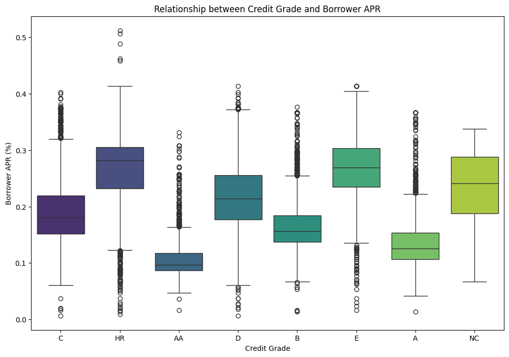

## Visualization 2: Scatter plot of Loan Amount and Borrower APR

## Comment:

This scatter plot explores the relationship between Loan Amount and Borrower APR. Utilizing a log scale on the x-axis enhances the visualization, emphasizing the non-linear dynamics between these variables. The alpha parameter adds transparency for improved visibility of overlapping points. Clear labels and a title enhance interpretability.

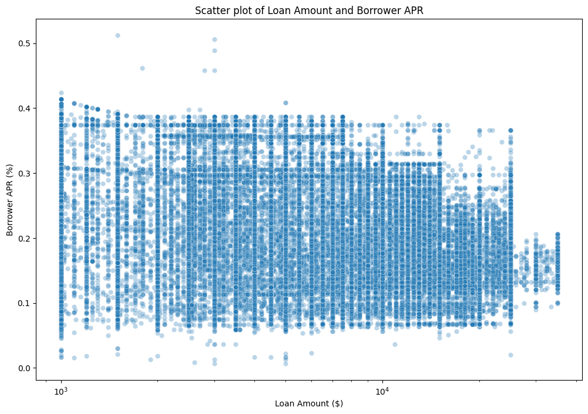

## # Visualization 3: Distribution of Borrower APR based on Loan Status

## Comment:

This boxplot visualizes the distribution of Borrower APR based on Loan Status. It provides insights into the variation of APR across different loan statuses. The exclusion of outliers enhances focus on the main distribution. Clear labels, a title, and rotated x-axis labels improve readability and interpretation.

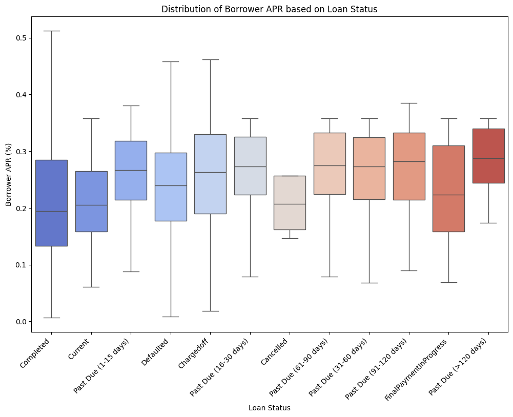